# Reporte 5A: Experimentos y análisis de algoritmos de intersección de conjuntos

# Introducción

Las operaciones de conjuntos, como la unión y la intersección, son esenciales en la ciencia de datos porque permiten estructurar, combinar y analizar información de manera precisa y coherente, ya que muy frecuentemente se tendrán bases de datos que provienen de múltiples fuentes, por lo que estas operaciones proporcionan un medio para manejar la diversidad y complejidad de los datos. Por ejemplo, la unión permite integrar registros de varias bases de datos para obtener una visión completa del fenómeno estudiado, mientras que la intersección ayuda a identificar los elementos que cumplen simultáneamente varios criterios, algo esencial para segmentación, filtrado y validación de información.

Dada la relevancia de las operaciones de conjuntos, en esta práctica nos enfocaremos en una de ellas: la intersección. Se realizará la implementación de tres diferentes algoritmos de intersección de conjuntos: Melding (ME), Baeza-Yates(BY) y Barbay & Kenyon (BK), usando tres diferentes parametrizaciones para el agoritmo BY, específicamente utilizando el algortimo de Búsqueda de Bisección / Búsqueda Binaria, el de Búsqueda no Acotada $B_1$, y el de Búsqueda no Acotada $B_2$. Para poder implementar los algortimos, se llevará a cabo la intersección de pares, de tripletas y de tetrapletas de listas, y posteriormente se analizarán y compararán los tiempos de ejecución y el número de comparaciones que requirió cada algoritmo para completar la tarea.

# Implementación de Algoritmos

Comenzamos cargando las librerías que se necesitarán para la práctica y también cargaremos los archivos que contienen los pares, tripletas y tetrapletas de listas que fungirán como nuestros conjuntos a intersectar.

```python
#Cargamos las librerías necesarias para la práctica
import numpy as np
import time
import copy
import pandas as pd
import json
import timeit
import random
import textwrap
import matplotlib.pyplot as plt
```

```python
from google.colab import drive
drive.mount('/content/drive')
```

### Algoritmo Melding (ME)

En el algoritmo Melding (ME) comparamos los valores de dos listas ordenadas $A$ y $B$ y vamos agregando a la lista de intersección aquellos valores que encontramos que son iguales. A continuación, creamos el código necesario para implementar este algoritmo.

```python
#Definimos una función para nuestro algoritmo Melding.
def melding(C,A,B):
  global comparaciones

  i = 0
  j = 0
  while i < len(A) and j < len(B):
    comparaciones += 1
    a, b = A[i], B[j]

    comparaciones += 1
    if a == b:
      C.append(a)
      i += 1
      j += 1
    elif a < b:
      i += 1
    elif a > b:
      j += 1

  return C
```

```python
#Hacemos un pequeño ejemplo para ver que funciona.
C = []
comparaciones = 0
A = [5,8,9,11,12,15,30,45,78,90]
B = [1,2,9,10,11,12,19,40,41,44,45]
melding(C, A, B)
print(C, comparaciones)
```

```
[9, 11, 12, 45] 30
```

### Algoritmo Baeza-Yates (BY)

En [1] el autor Ricardo Baeza-Yates propone un algoritmo de intersección de dos listas ordenadas $A$ de tamaño $m$ y $B$ de tamaño $n$, que consiste en utilizar la mediana de $A$ como pivote; se busca la posición de inserción de esta mediana dentro de la lista $B$ y, así, se divide el problema en tres intersecciones menores: $\{A[0:M-1]\}\cap \{B[0:p-e]\}$, $\{A[M]\}\cap\{B[p]\}$ y $\{A[M+1:m]\}\cap \{B[p+e:n]\}$, con $p$ la posición de inserción de la mediana en la lista B, $e=1$ si $A[M]=B[p]$ y $e=0$ en caso contrario. Después se aplica de manera iterativa en la primera y última parte de la lista.

Para implementar el algoritmo BY, primero necesitamos un algoritmo de búsqueda para obtener las posiciones de inserción necesarias; en este caso programamos el algoritmo de Búsqueda Binaria, Búsqueda no Acotada $B_1$ y Búsqueda no Acotada $B_2$. De la unidad previa se tenía el código de tres funciones que implementaban dicho algoritmos; sin embargo, será necesario hacer algunas modificaciones, ya que en esta ocasión adicionalmente requerimos agregar como argumento la posición en la que deseamos iniciar la búsqueda del índice de inserción. De igual manera, dado que la función del algoritmo BY llamará a estos algoritmos, necesitamos que los tres tengan los mismos argumentos y en el mismo orden para poder definir una sola función de BY.

```python
#Definimos una función para el algoritmo de búsqueda binaria.
def busqueda_binaria(A,x,p):
  global comparaciones

  inicio = p
  fin = len(A) - 1
  while inicio < fin:

    pmedio = (inicio + fin) // 2
    if x <= A[pmedio]:
      comparaciones += 1
      fin = pmedio
    else:
      comparaciones += 1
      inicio = pmedio + 1

  if x > A[fin]:
    fin += 1
  comparaciones += 1 #Sumamamos una comparación por el if del final
  return fin
```

```python
#Creamos una función para el algoritmo de Búsqueda no Acotada B1.
def busqueda_b1(A, x, p):
  global comparaciones
  n=len(A)


  if p >= n:
    return n

  comparaciones += 1
  if x <= A[p]:
    return p

  j=0
  i=1

  while (p + 2**i-1) < n and x > A[p + 2**i-1]:
    comparaciones += 1
    j=i
    i += 1

  comparaciones += 1
  return busqueda_binaria(A[p+2**j-1:min(p+2**(i),n)], x, 0) + p + 2**j - 1 #Sumamos 2^j-1, porque la búsqueda binaria es dentro de una lista recortada en la que se están recorriendo esa cantidad de índices.
```

```python
#Creamos una función para el algoritmo de Búsqueda no Acotada B2.
def busqueda_b2(A,x,p):
  global comparaciones
  n=len(A)


  if p >= n:
    return n

  comparaciones += 1
  if x <= A[p]:
    return p

  j=0
  i=1

  while p + 2**(2**i)-1 < n and x>A[p + 2**(2**i)-1]:
    comparaciones += 1
    j=i
    i += 1

  comparaciones += 1

  #Tratamos demanera adicional el caso en el que el valor de consulta es menor que el primer valor comparado
  if j==0:
    inicio=p
  else:
    inicio=p+2**(2**j)-1


  return busqueda_binaria(A[inicio:min(p+2**(2**i),n)], x, 0) + inicio #Sumamos la variable inicio, porque la búsqueda binaria es dentro de una lista recortada en la que se están recorriendo esa cantidad de índices.
```

Una vez modificadas nuestras funciones de algoritmos de búsqueda, podemos hacer la función correspondiente al algorimto Baeza-Yates.

```python
#Creamos nuestra función del algortimo Baeza-Yates
def by(C, A, a_sp, a_ep, B, b_sp, b_ep, busqueda):
  global comparaciones

  comparaciones += 1
  if a_ep < a_sp or b_ep < b_sp:
    return C

  imediana = (a_sp+a_ep)//2
  M = A[imediana]
  pM = min(busqueda(B, M, b_sp), b_ep)

  comparaciones += 1
  if M == B[pM]:
    e = 1
  else:
    e = 0

  by(C, A, a_sp, imediana-1, B, b_sp, pM-e, busqueda)

  comparaciones += 1
  if e == 1:
    C.append(M)

  by(C, A, imediana+1, a_ep, B, pM+e, b_ep, busqueda)

  return C
```

```python
#Hacemos una prueba para ver que funcionan las funciones del algoritmo BY.
C = []
comparaciones = 0
A = [5,8,9,11,12,15,30,45,78,90]
B = [1,2,9,10,11,12,19,40,41,44,45]
by(C, A, 0, len(A)-1, B, 0, len(B)-1, busqueda_binaria)
print(C, comparaciones)
C = []
comparaciones = 0
by(C, A, 0, len(A)-1, B, 0, len(B)-1, busqueda_b1)
print(C, comparaciones)
C = []
comparaciones = 0
by(C, A, 0, len(A)-1, B, 0, len(B)-1, busqueda_b2)
print(C, comparaciones)
```

```
[9, 11, 12, 45] 65
[9, 11, 12, 45] 68
[9, 11, 12, 45] 67
```

### Algoritmo Barbay & Kenyon (BK)

En [2] se presenta el algoritmo que denominaremos como Barbay & Kenyon por los autores del mismo. Este algoritmo consiste en buscar un valor en diferentes listas de valores ordenados a través de su posición de inserción en cada lista, llevando un conteo de en cuántas listas está presente para que, si se encuentra en todas, sea agregado al conjunto intersección.

Creamos la función del algortimo Barbay & Kenyon, mismo que también requiere de un algoritmo de búsqueda que, en este caso será el de Búsqueda no Acotada B1.

```python
#Función para implementar el algoritmo Barbay & Kenyon.
def bk(C, L, busqueda):
    global comparaciones

    n = len(L)

    comparaciones += 1
    if n == 0:
        return C

    P = [0] * n
    el = min(L[i][0] for i in range(n))

    while True:
        for i in range(n):
            P[i] = busqueda(L[i], el, P[i])

            comparaciones += 1
            if P[i] >= len(L[i]):
                return C
            pval = L[i][P[i]]

            comparaciones += 1
            if pval == el:
                continue
            else:
                el = pval
                break
        else:
            C.append(el)
            for j in range(n):

                comparaciones += 1
                if P[j] < len(L[j]) and L[j][P[j]] == el:
                    P[j] += 1

                    comparaciones += 1
                    if P[j] >= len(L[j]):
                        return C
            el = min(L[j][P[j]] for j in range(n) if P[j] < len(L[j]))
            continue
```

```python
#hacemos un pequeño ejemplo para ver que funciona.
D = []
comparaciones = 0
A = [5,8,9,11,12,15,30,45,78,90]
B = [1,2,9,9,9,10,11,12,15,19,40,41,44,45]
C = [2,7,9,15,15,15,34,44,45]
L = [A,B,C]
bk(D, L, busqueda_b1)
print(D, comparaciones)
```

```
[9, 15, 45] 121
```

Con todo lo necesario para poder implementar los algoritmos, procedemos a leer nuestros archivos en formato JSON.

```python
#Cargamos el conjunto A que tiene doscientos pares de listas.
with open("/content/drive/MyDrive/MCDI/Análisis de Algoritmos/Reporte5A/postinglists-for-intersection-A-k=2.json", "r", encoding="utf-8") as archivo:
    A = json.load(archivo)
```

```python
#Cargamos el conjunto B que tiene doscientos tripletas de listas.
with open("/content/drive/MyDrive/MCDI/Análisis de Algoritmos/Reporte5A/postinglists-for-intersection-B-k=3.json", "r", encoding="utf-8") as archivo:
    B = json.load(archivo)
```

```python
#Cargamos el conjunto C que tiene doscientos tetrapletas de listas.
with open("/content/drive/MyDrive/MCDI/Análisis de Algoritmos/Reporte5A/postinglists-for-intersection-C-k=4.json", "r", encoding="utf-8") as archivo:
    C = json.load(archivo)
```

```python
#Vemos qué forma tienen nuestros conjuntos a intersectar.
print(len(A), len(A[0]))
print(len(B), len(B[0]))
print(len(C), len(C[0]))
```

```
200 2
200 3
200 4
```

```python
#Verificamos que las listas de los conjuntos estén ordenadas:
for i in range(len(A)):
  for j in range(len(A[i])):
    for k in range(len(A[i][j])-1):
      if A[i][j][k]>A[i][j][k+1]:
        print("A no está ordenado")

for i in range(len(B)):
  for j in range(len(B[i])):
    for k in range(len(B[i][j])-1):
      if B[i][j][k]>B[i][j][k+1]:
        print("B no está ordenado")

for i in range(len(C)):
  for j in range(len(C[i])):
    for k in range(len(C[i][j])-1):
      if C[i][j][k]>C[i][j][k+1]:
        print("C no está ordenado")
```

Vemos que A tiene doscientos pares de listas, B tiene doscientas tripletas de listas y C tiene doscientas tetrapletas de listas. Adicionalmente, ya verificamos que nuestras listas están ordenadas, por lo que ya estamos en condiciones de usar los algoritmos para la intersección de conjuntos; sin embargo, primero creamos un diccionario en donde almacenaremos los resultados obtenidos: el tiempo de ejecución para cada intersección, el número de comparaciones requeridas, la longitud de intersecciones y el resultado de intersectar los conjuntos.

```python
resultados = {
    "A": {
        "ME": {"tiempo": [], "comparaciones": [], "longitud": [], "intersec": []},
        "BYB": {"tiempo": [], "comparaciones": [], "longitud": [], "intersec": []},
        "BYB1": {"tiempo": [], "comparaciones": [], "longitud": [], "intersec": []},
        "BYB2": {"tiempo": [], "comparaciones": [], "longitud": [], "intersec": []},
        "BK": {"tiempo": [], "comparaciones": [], "longitud": [], "intersec": []}
    },
    "B": {
        "ME": {"tiempo": [], "comparaciones": [], "longitud": [], "intersec": []},
        "BYB": {"tiempo": [], "comparaciones": [], "longitud": [], "intersec": []},
        "BYB1": {"tiempo": [], "comparaciones": [], "longitud": [], "intersec": []},
        "BYB2": {"tiempo": [], "comparaciones": [], "longitud": [], "intersec": []},
        "BK": {"tiempo": [], "comparaciones": [], "longitud": [], "intersec": []}
    },
    "C": {
        "ME": {"tiempo": [], "comparaciones": [], "longitud": [], "intersec": []},
        "BYB": {"tiempo": [], "comparaciones": [], "longitud": [], "intersec": []},
        "BYB1": {"tiempo": [], "comparaciones": [], "longitud": [], "intersec": []},
        "BYB2": {"tiempo": [], "comparaciones": [], "longitud": [], "intersec": []},
        "BK": {"tiempo": [], "comparaciones": [], "longitud": [], "intersec": []}
    }
}
```

### Intersecciones del conjunto A

```python
#Implementación del algoritmo Melding (ME)
for i in range(len(A)):
  I = [] #lista con la intersección
  comparaciones = 0
  inicio = time.perf_counter()
  melding(I, A[i][0], A[i][1])
  fin = time.perf_counter()
  resultados["A"]["ME"]["tiempo"].append(fin - inicio)
  resultados["A"]["ME"]["comparaciones"].append(comparaciones)
  resultados["A"]["ME"]["longitud"].append(len(I))
  resultados["A"]["ME"]["intersec"].append(I)
```

```python
#Implementación del algoritmo Baeza-Yates parametrizado con Búsqueda Binaria/Bisección (BYB)
for i in range(len(A)):
  I = [] #lista con la intersección
  comparaciones = 0
  inicio = time.perf_counter()
  by(I, A[i][0], 0, len(A[i][0])-1, A[i][1], 0, len(A[i][1])-1, busqueda_binaria)
  fin = time.perf_counter()
  resultados["A"]["BYB"]["tiempo"].append(fin - inicio)
  resultados["A"]["BYB"]["comparaciones"].append(comparaciones)
  resultados["A"]["BYB"]["longitud"].append(len(I))
  resultados["A"]["BYB"]["intersec"].append(I)
```

```python
#Implementación del algoritmo Baeza-Yates parametrizado con Búsqueda no Acotada B1 (BYB1)
for i in range(len(A)):
  I = [] #lista con la intersección
  comparaciones = 0
  inicio = time.perf_counter()
  by(I, A[i][0], 0, len(A[i][0])-1, A[i][1], 0, len(A[i][1])-1, busqueda_b1)
  fin = time.perf_counter()
  resultados["A"]["BYB1"]["tiempo"].append(fin - inicio)
  resultados["A"]["BYB1"]["comparaciones"].append(comparaciones)
  resultados["A"]["BYB1"]["longitud"].append(len(I))
  resultados["A"]["BYB1"]["intersec"].append(I)
```

```python
#Implementación del algoritmo Baeza-Yates parametrizado con Búsqueda no Acotada B2 (BYB2)
for i in range(len(A)):
  I = [] #lista con la intersección
  comparaciones = 0
  inicio = time.perf_counter()
  by(I, A[i][0], 0, len(A[i][0])-1, A[i][1], 0, len(A[i][1])-1, busqueda_b2)
  fin = time.perf_counter()
  resultados["A"]["BYB2"]["tiempo"].append(fin - inicio)
  resultados["A"]["BYB2"]["comparaciones"].append(comparaciones)
  resultados["A"]["BYB2"]["longitud"].append(len(I))
  resultados["A"]["BYB2"]["intersec"].append(I)
```

```python
#Implementación del algoritmo Barbay & Kenyon (BK)
for i in range(len(A)):
  I = [] #lista con la intersección
  comparaciones = 0
  inicio = time.perf_counter()
  bk(I, A[i], busqueda_b1)
  fin = time.perf_counter()
  resultados["A"]["BK"]["tiempo"].append(fin - inicio)
  resultados["A"]["BK"]["comparaciones"].append(comparaciones)
  resultados["A"]["BK"]["longitud"].append(len(I))
  resultados["A"]["BK"]["intersec"].append(I)
```

Hacemos una prueba con la primera intersección para ver que obtuvimos los mismos resultados con las cinco implementaciones:

```python
print(resultados["A"]["ME"]["intersec"][0])
print(resultados["A"]["BYB"]["intersec"][0])
print(resultados["A"]["BYB1"]["intersec"][0])
print(resultados["A"]["BYB2"]["intersec"][0])
print(resultados["A"]["BK"]["intersec"][0])
```

```
[6323, 12498]
[6323, 12498]
[6323, 12498]
[6323, 12498]
[6323, 12498]
```

### Intersecciones del conjunto B

```python
#Implementación del algoritmo Melding (ME)
for i in range(len(B)):
  I = [] #lista con la primera intersección
  I2 = [] #Lista con la intersección final
  comparaciones = 0
  inicio = time.perf_counter()
  melding(I, B[i][0], B[i][1])
  melding(I2,I,B[i][2])
  fin = time.perf_counter()
  resultados["B"]["ME"]["tiempo"].append(fin - inicio)
  resultados["B"]["ME"]["comparaciones"].append(comparaciones)
  resultados["B"]["ME"]["longitud"].append(len(I2))
  resultados["B"]["ME"]["intersec"].append(I2)
```

```python
#Implementación del algoritmo Baeza-Yates parametrizado con Búsqueda Binaria/Bisección (BYB)
for i in range(len(B)):
  I = [] #lista con la primera intersección
  I2= [] #lista con la intersección final
  comparaciones = 0
  inicio = time.perf_counter()
  by(I, B[i][0], 0, len(B[i][0])-1, B[i][1], 0, len(B[i][1])-1, busqueda_binaria)
  by(I2, I, 0, len(I)-1, B[i][2], 0, len(B[i][2])-1, busqueda_binaria)
  fin = time.perf_counter()
  resultados["B"]["BYB"]["tiempo"].append(fin - inicio)
  resultados["B"]["BYB"]["comparaciones"].append(comparaciones)
  resultados["B"]["BYB"]["longitud"].append(len(I2))
  resultados["B"]["BYB"]["intersec"].append(I2)
```

```python
#Implementación del algoritmo Baeza-Yates parametrizado con Búsqueda no Acotada B1 (BYB1)
for i in range(len(B)):
  I = [] #lista con la primera intersección
  I2= [] #lista con la intersección final
  comparaciones = 0
  inicio = time.perf_counter()
  by(I, B[i][0], 0, len(B[i][0])-1, B[i][1], 0, len(B[i][1])-1, busqueda_b1)
  by(I2, I, 0, len(I)-1, B[i][2], 0, len(B[i][2])-1, busqueda_b1)
  fin = time.perf_counter()
  resultados["B"]["BYB1"]["tiempo"].append(fin - inicio)
  resultados["B"]["BYB1"]["comparaciones"].append(comparaciones)
  resultados["B"]["BYB1"]["longitud"].append(len(I2))
  resultados["B"]["BYB1"]["intersec"].append(I2)
```

```python
#Implementación del algoritmo Baeza-Yates parametrizado con Búsqueda no Acotada B2 (BYB2)
for i in range(len(B)):
  I = [] #lista con la primera intersección
  I2= [] #lista con la intersección final
  comparaciones = 0
  inicio = time.perf_counter()
  by(I, B[i][0], 0, len(B[i][0])-1, B[i][1], 0, len(B[i][1])-1, busqueda_b2)
  by(I2, I, 0, len(I)-1, B[i][2], 0, len(B[i][2])-1, busqueda_b2)
  fin = time.perf_counter()
  resultados["B"]["BYB2"]["tiempo"].append(fin - inicio)
  resultados["B"]["BYB2"]["comparaciones"].append(comparaciones)
  resultados["B"]["BYB2"]["longitud"].append(len(I2))
  resultados["B"]["BYB2"]["intersec"].append(I2)
```

```python
#Implementación del algoritmo Barbay & Kenyon (BK)
for i in range(len(B)):
  I = [] #lista con la intersección
  comparaciones = 0
  inicio = time.perf_counter()
  bk(I, B[i], busqueda_b1)
  fin = time.perf_counter()
  resultados["B"]["BK"]["tiempo"].append(fin - inicio)
  resultados["B"]["BK"]["comparaciones"].append(comparaciones)
  resultados["B"]["BK"]["longitud"].append(len(I))
  resultados["B"]["BK"]["intersec"].append(I)
```

Hacemos una prueba con la primera intersección para ver que obtuvimos los mismos resultados con las cinco implementaciones:

```python
print(resultados["B"]["ME"]["intersec"][0])
print(resultados["B"]["BYB"]["intersec"][0])
print(resultados["B"]["BYB1"]["intersec"][0])
print(resultados["B"]["BYB2"]["intersec"][0])
print(resultados["B"]["BK"]["intersec"][0])
```

```
[5239, 6162, 6806, 7411, 8951, 11279]
[5239, 6162, 6806, 7411, 8951, 11279]
[5239, 6162, 6806, 7411, 8951, 11279]
[5239, 6162, 6806, 7411, 8951, 11279]
[5239, 6162, 6806, 7411, 8951, 11279]
```

### Intersecciones del conjunto C

```python
#Implementación del algoritmo Melding (ME)
for i in range(len(C)):
  I = [] #Lista con la primera intersección
  I2 = [] #Lista con la segunda intersección
  I3 = [] #Lista con la intersección final
  comparaciones = 0
  inicio = time.perf_counter()
  melding(I, C[i][0], C[i][1])
  melding(I2,I,C[i][2])
  melding(I3,I2,C[i][3])
  fin = time.perf_counter()
  resultados["C"]["ME"]["tiempo"].append(fin - inicio)
  resultados["C"]["ME"]["comparaciones"].append(comparaciones)
  resultados["C"]["ME"]["longitud"].append(len(I3))
  resultados["C"]["ME"]["intersec"].append(I3)
```

```python
#Implementación del algoritmo Baeza-Yates parametrizado con Búsqueda Binaria/Bisección (BYB)
for i in range(len(C)):
  I = [] #Lista con la primera intersección
  I2 = [] #Lista con la segunda intersección
  I3 = [] #Lista con la intersección final
  comparaciones = 0
  inicio = time.perf_counter()
  by(I, C[i][0], 0, len(C[i][0])-1, C[i][1], 0, len(C[i][1])-1, busqueda_binaria)
  by(I2, I, 0, len(I)-1, C[i][2], 0, len(C[i][2])-1, busqueda_binaria)
  by(I3, I2, 0, len(I2)-1, C[i][3], 0, len(C[i][3])-1, busqueda_binaria)
  fin = time.perf_counter()
  resultados["C"]["BYB"]["tiempo"].append(fin - inicio)
  resultados["C"]["BYB"]["comparaciones"].append(comparaciones)
  resultados["C"]["BYB"]["longitud"].append(len(I3))
  resultados["C"]["BYB"]["intersec"].append(I3)
```

```python
#Implementación del algoritmo Baeza-Yates parametrizado con Búsqueda no Acotada B1 (BYB1)
for i in range(len(C)):
  I = [] #Lista con la primera intersección
  I2 = [] #Lista con la segunda intersección
  I3 = [] #Lista con la intersección final
  comparaciones = 0
  inicio = time.perf_counter()
  by(I, C[i][0], 0, len(C[i][0])-1, C[i][1], 0, len(C[i][1])-1, busqueda_b1)
  by(I2, I, 0, len(I)-1, C[i][2], 0, len(C[i][2])-1, busqueda_b1)
  by(I3, I2, 0, len(I2)-1, C[i][3], 0, len(C[i][3])-1, busqueda_b1)
  fin = time.perf_counter()
  resultados["C"]["BYB1"]["tiempo"].append(fin - inicio)
  resultados["C"]["BYB1"]["comparaciones"].append(comparaciones)
  resultados["C"]["BYB1"]["longitud"].append(len(I3))
  resultados["C"]["BYB1"]["intersec"].append(I3)
```

```python
#Implementación del algoritmo Baeza-Yates parametrizado con Búsqueda no Acotada B2 (BYB2)
for i in range(len(C)):
  I = [] #Lista con la primera intersección
  I2 = [] #Lista con la segunda intersección
  I3 = [] #Lista con la intersección final
  comparaciones = 0
  inicio = time.perf_counter()
  by(I, C[i][0], 0, len(C[i][0])-1, C[i][1], 0, len(C[i][1])-1, busqueda_b2)
  by(I2, I, 0, len(I)-1, C[i][2], 0, len(C[i][2])-1, busqueda_b2)
  by(I3, I2, 0, len(I2)-1, C[i][3], 0, len(C[i][3])-1, busqueda_b2)
  fin = time.perf_counter()
  resultados["C"]["BYB2"]["tiempo"].append(fin - inicio)
  resultados["C"]["BYB2"]["comparaciones"].append(comparaciones)
  resultados["C"]["BYB2"]["longitud"].append(len(I3))
  resultados["C"]["BYB2"]["intersec"].append(I3)
```

```python
#Implementación del algoritmo Barbay & Kenyon (BK)
for i in range(len(C)):
  I = [] #lista con la intersección
  comparaciones = 0
  inicio = time.perf_counter()
  bk(I, C[i], busqueda_b1)
  fin = time.perf_counter()
  resultados["C"]["BK"]["tiempo"].append(fin - inicio)
  resultados["C"]["BK"]["comparaciones"].append(comparaciones)
  resultados["C"]["BK"]["longitud"].append(len(I))
  resultados["C"]["BK"]["intersec"].append(I)
```

```python
print(resultados["C"]["ME"]["intersec"][1])
print(resultados["C"]["BYB"]["intersec"][1])
print(resultados["C"]["BYB1"]["intersec"][1])
print(resultados["C"]["BYB2"]["intersec"][1])
print(resultados["C"]["BK"]["intersec"][1])
```

```
[41697, 41975]
[41697, 41975]
[41697, 41975]
[41697, 41975]
[41697, 41975]
```

Ya aplicados todos los algoritmos de intersección de conjuntos, procederemos a hacer la comparación de los mismos con base en el tiempo de ejecución requerido para cada intersección y el número de comparaciones realizadas por el algoritmo de intersección.

# Comparación de Resultados

Para poder hacer la comparación de los algoritmos, procedemos a realizar gráficos Boxplot para los tiempos de ejecución y el número de comparaciones necesitadas por los algoritmos para hacer las 200 intersecciones de cada conjunto.

### Longitud de las intersecciones

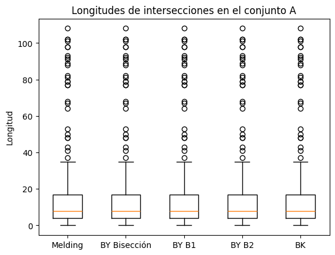

```python
#Generamos el gráfico Boxplot para las longitudes de intersecciones en el conjunto A.
longitudes_A = [
    resultados["A"]["ME"]["longitud"],
    resultados["A"]["BYB"]["longitud"],
    resultados["A"]["BYB1"]["longitud"],
    resultados["A"]["BYB2"]["longitud"],
    resultados["A"]["BK"]["longitud"]
]

plt.figure()
plt.boxplot(longitudes_A)
plt.xticks([1,2,3,4,5], ["Melding", "BY Bisección", "BY B1", "BY B2","BK"])
plt.title("Longitudes de intersecciones en el conjunto A")
plt.ylabel("Longitud")
plt.show()
```

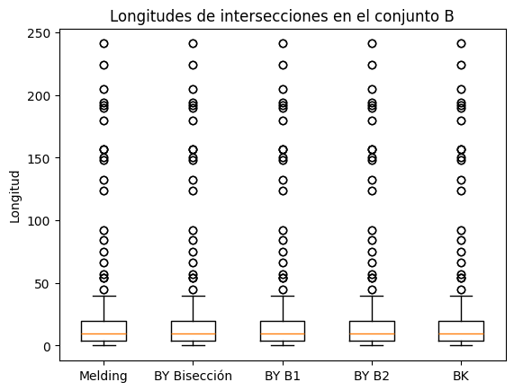

```python
#Generamos el gráfico Boxplot para las longitudes de intersecciones en el conjunto B.
longitudes_B = [
    resultados["B"]["ME"]["longitud"],
    resultados["B"]["BYB"]["longitud"],
    resultados["B"]["BYB1"]["longitud"],
    resultados["B"]["BYB2"]["longitud"],
    resultados["B"]["BK"]["longitud"]
]

plt.figure()
plt.boxplot(longitudes_B)
plt.xticks([1,2,3,4,5], ["Melding", "BY Bisección", "BY B1", "BY B2","BK"])
plt.title("Longitudes de intersecciones en el conjunto B")
plt.ylabel("Longitud")
plt.show()
```

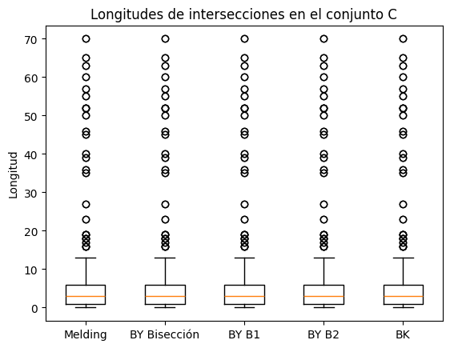

```python
#Generamos el gráfico Boxplot para las longitudes de intersecciones en el conjunto C.
longitudes_C = [
    resultados["C"]["ME"]["longitud"],
    resultados["C"]["BYB"]["longitud"],
    resultados["C"]["BYB1"]["longitud"],
    resultados["C"]["BYB2"]["longitud"],
    resultados["C"]["BK"]["longitud"],
    #longitudes_listasC[0:199]
]

plt.figure()
plt.boxplot(longitudes_C)
plt.xticks([1,2,3,4,5], ["Melding", "BY Bisección", "BY B1", "BY B2", "BK"])
plt.title("Longitudes de intersecciones en el conjunto C")
plt.ylabel("Longitud")
plt.show()
```

Análisis: En los tres gráficos obtenemos exactamente los mismos gráficos que contienen la longitud de las intersecciones obtenidas, por lo que concluimos que se encuentran correctos, o al menos todos coinciden.

### Tiempos de ejecución

Una vez verificado que obtenemos los mismos resultados para los cinco algoritmos implementados, realizamos el análisis de los tiempos de ejecución necesarios para cada uno de ellos.

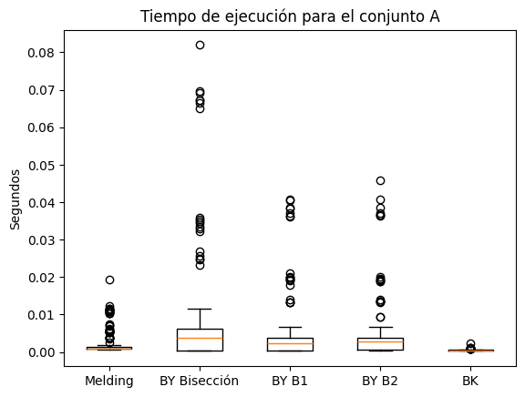

```python
#Generamos el gráfico Boxplot para los tiempos de ejecución de intersecciones en el conjunto A.
tiempos_A = [
    resultados["A"]["ME"]["tiempo"],
    resultados["A"]["BYB"]["tiempo"],
    resultados["A"]["BYB1"]["tiempo"],
    resultados["A"]["BYB2"]["tiempo"],
    resultados["A"]["BK"]["tiempo"]
]

plt.figure()
plt.boxplot(tiempos_A)
plt.xticks([1,2,3,4,5], ["Melding", "BY Bisección", "BY B1", "BY B2","BK"])
plt.title("Tiempo de ejecución para el conjunto A")
plt.ylabel("Segundos")
plt.show()
```

Análisis: Para el conjunto de pares de listas vemos que el algoritmo Baeza-Yates parametrizado con el algoritmo de búsqueda de Bisección es el que presenta los tiempos de ejecución más grandes, lo cual era de esperarse ya que sabemos, dentro de los tres algoritmos de búsqueda utilizados, el de Bisección es el más tardado de todos, por lo que esto influye en la implementación del algoritmo de intersección. El mismo algoritmo parametrizado con Búsqueda $B_1$ y $B_2$ muestra resultados parecidos entre sí. El algoritmo Melding presenta mejores tiempos de ejecución que el de Baeza-Yates, pero no tan buenos como los de Barbay & Kenyon, que supera en gran magnitud a todos los demás.

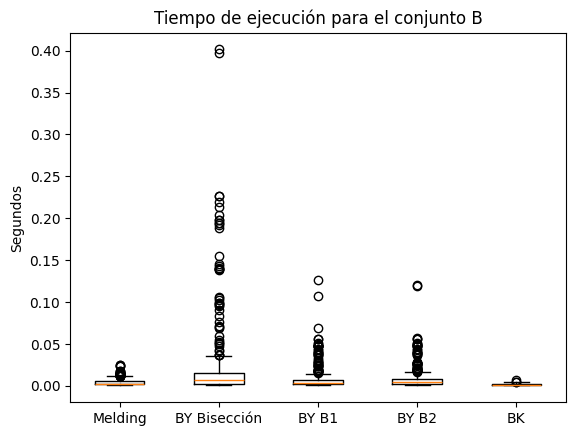

```python
#Generamos el gráfico Boxplot para los tiempos de ejecución de intersecciones en el conjunto B.
tiempos_B = [
    resultados["B"]["ME"]["tiempo"],
    resultados["B"]["BYB"]["tiempo"],
    resultados["B"]["BYB1"]["tiempo"],
    resultados["B"]["BYB2"]["tiempo"],
    resultados["B"]["BK"]["tiempo"]
]

plt.figure()
plt.boxplot(tiempos_B)
plt.xticks([1,2,3,4,5], ["Melding", "BY Bisección", "BY B1", "BY B2","BK"])
plt.title("Tiempo de ejecución para el conjunto B")
plt.ylabel("Segundos")
plt.show()
```

Análisis: Para el conjunto de tripletas de listas nuevamente el algoritmo Baeza-Yates parametrizado con el algoritmo de búsqueda de Bisección es el del peor rendimiento, resultado que no sorprende por el algoritmo de búsqueda utilizado. Las parametrizaciones con Búsqueda $B_1$ y $B_2$ de nueva cuenta presentan resultados similares entre sí. El algoritmo Melding presenta mucho mejores tiempos de ejecución que el de Baeza-Yates, quedando relativamente cercano a los de Barbay & Kenyon, que repiten tener el mejor rendimiento de los cinco algoritmos.

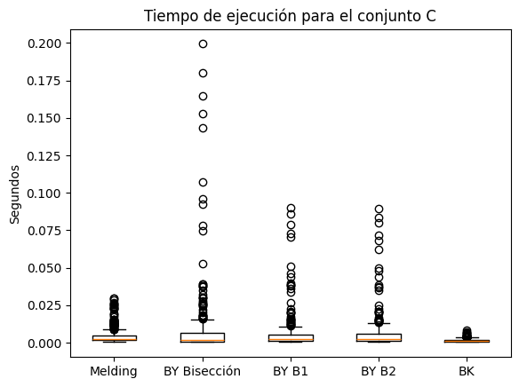

```python
#Generamos el gráfico Boxplot para los tiempos de ejecución de intersecciones en el conjunto C.
tiempos_C = [
    resultados["C"]["ME"]["tiempo"],
    resultados["C"]["BYB"]["tiempo"],
    resultados["C"]["BYB1"]["tiempo"],
    resultados["C"]["BYB2"]["tiempo"],
    resultados["C"]["BK"]["tiempo"]
]

plt.figure()
plt.boxplot(tiempos_C)
plt.xticks([1,2,3,4,5], ["Melding", "BY Bisección", "BY B1", "BY B2","BK"])
plt.title("Tiempo de ejecución para el conjunto C")
plt.ylabel("Segundos")
plt.show()
```

Análisis: Para el último conjunto que consta de tetrapletas de listas la tendencia de resultados se repite por tercer ocasión, aunque en este caso el algoritmo Melding se alejó del rendimiento del algoritmo BK en comparación con los resultados obtenidos en la intersección de tripletas.

### Número de comparaciones

Ahora se realiza un contraste en el número de comparaciones que cada algoritmo requirió para finalizar las intersecciones de los conjuntos.

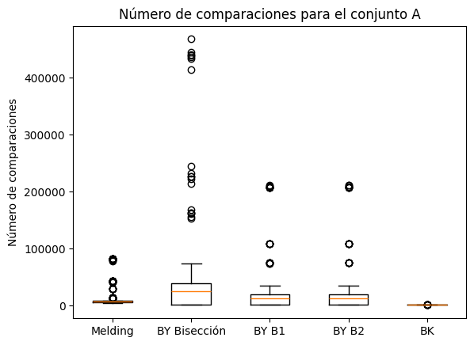

```python
#Generamos el gráfico Boxplot para número de comparaciones en las intersecciones en el conjunto A.
comparaciones_A = [
    resultados["A"]["ME"]["comparaciones"],
    resultados["A"]["BYB"]["comparaciones"],
    resultados["A"]["BYB1"]["comparaciones"],
    resultados["A"]["BYB2"]["comparaciones"],
    resultados["A"]["BK"]["comparaciones"]
]

plt.figure()
plt.boxplot(comparaciones_A)
plt.xticks([1,2,3,4,5], ["Melding", "BY Bisección", "BY B1", "BY B2","BK"])
plt.title("Número de comparaciones para el conjunto A")
plt.ylabel("Número de comparaciones")
plt.ticklabel_format(style='plain', axis='y')
plt.show()
```

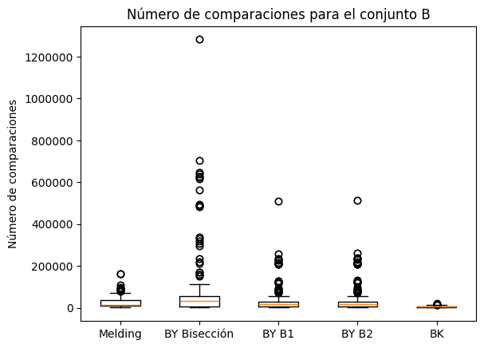

```python
#Generamos el gráfico Boxplot para número de comparaciones en las intersecciones en el conjunto B.
comparaciones_B = [
    resultados["B"]["ME"]["comparaciones"],
    resultados["B"]["BYB"]["comparaciones"],
    resultados["B"]["BYB1"]["comparaciones"],
    resultados["B"]["BYB2"]["comparaciones"],
    resultados["B"]["BK"]["comparaciones"]
]

plt.figure()
plt.boxplot(comparaciones_B)
plt.xticks([1,2,3,4,5], ["Melding", "BY Bisección", "BY B1", "BY B2","BK"])
plt.title("Número de comparaciones para el conjunto B")
plt.ylabel("Número de comparaciones")
plt.ticklabel_format(style='plain', axis='y')
plt.show()
```

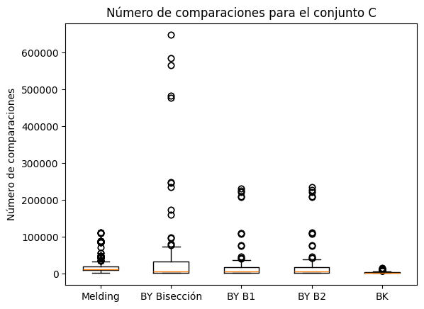

```python
#Generamos el gráfico Boxplot para número de comparaciones en las intersecciones en el conjunto C.
comparaciones_C = [
    resultados["C"]["ME"]["comparaciones"],
    resultados["C"]["BYB"]["comparaciones"],
    resultados["C"]["BYB1"]["comparaciones"],
    resultados["C"]["BYB2"]["comparaciones"],
    resultados["C"]["BK"]["comparaciones"]
]

plt.figure()
plt.boxplot(comparaciones_C)
plt.xticks([1,2,3,4,5], ["Melding", "BY Bisección", "BY B1", "BY B2","BK"])
plt.title("Número de comparaciones para el conjunto C")
plt.ylabel("Número de comparaciones")
plt.ticklabel_format(style='plain', axis='y')
plt.show()
```

Análisis: En este caso se realiza un análisis en conjunto para las tres gráficas, ya que, si bien estamos graficando otro tipo de datos, vemos que la tendencia obtenida es la misma que se obtuvo en la comparación de tiempos de ejcución. Nuevamente el algoritmo Barbay & Kenyon supera por mucho a los otros algoritmos de interección. De nueva cuenta, el algoritmo de Baeza-Yates parametrizado con el algoritmo de Búsqueda de Bisección fue el que obtuvo los peores resultados para los tres conjuntos, necesitando una cantidad de comparaciones mucho mayor que la que requirieron los demás algoritmos. Los algoritmos Melding, Baeza-Yates con Búsqueda B1 y Baeza-Yates con Búsqueda B2 presentaron resultados buenos y, relativamente, similares entre sí.

# Conclusiones

Al implementar los cinco algoritmos de intersección obtenemos una tendencia similar para los tres conjuntos utilizados, independientemente de si fue intersección de pares, tripletas o tetrapletas de listas ordenadas. El algoritmo Barbay & Kenyon fue el que demostró obtener la mejor eficiencia, tanto en tiempo de ejecución como en número de comparaciones requeridas para generar las intersecciones. Los algoritmos Melding, Baeza-Yates con Búsqueda $B_1$ y Baeza-Yates con Búsqueda $B_2$ presentaron un rendimiento intermedio, aunque el algoritmo Melding fue ligeramente mejor tanto en tiempos de ejecución como en número de comparaciones requeridas. Finalmente, el algoritmo Baeza-Yates con Búsqueda de Bisección fue el que siempre presentó los peores resultados en cuestión de eficiencia, tanto en términos de tiempo de ejecución como en número de comparaciones realziadas; sin embargo, esto era de esperarse, ya que este algoritmo resulta más lento que el de búsqueda $B_1$ y $B_2$, pues, si bien estos dos algoritmos también utilizan Búsqueda Binaria dentro de sí, lo hacen en tramos más cortos.

En conclusión, se podría decir que el algoritmo de Barbay & Kenyon resulta el mejor a utilizar para intersectar conjuntos, independientemente del número de conjuntos que se tengan que intersectar ni las longitudes de estos, ya que vimos que para todas las intersecciones realizadas, BK siempre tuvo un rendimiento muy similar, a diferencia de los otros algoritmos en los que sí había una mayor desviación en los tiempos de ejecución y número de comparaciones realizadas.

# Referencias

[1] Baeza-Yates, R. (2004). A Fast Set Intersection Algorithm for Sorted Sequences. Springer.

[2] Barbay, J. and Kenyon, C. (2002). Adaptive Intersection and t-Threshold Problems. Society for Industrial and Applied Mathematics.